# Demand Forecasting - Feature Engineering

```r
#if(!require(bayesian_first_aid)){devtools::install_github("rasmusab/bayesian_first_aid")}
if(!require(easypackages)){install.packages("easypackages")}
library(easypackages)
packages("plyr","dplyr","ggplot2", "readr", "tidyr", "gridExtra", "stringr", "lubridate",
        "caret",  prompt = TRUE)

options(scipen = 999)#Do not display exponents
load("~/Github/LargeFiles/DemandForecast.RData")
```

# Introduction

This experiment demonstrates demand estimation using regression with UCI bike rental data.

This experiment demonstrates the **feature engineering** process for building a regression model using bike rental demand prediction as an example. We demonstrate that effective feature engineering will lead to a more accurate model.

# Data

The Bike Rental UCI dataset is used as the input raw data for this experiment. This dataset is based on real data from the Capital Bikeshare company, which operates a bike rental network in Washington DC in the United States.

The dataset contains 17,379 rows and 17 columns, each row representing the number of bike rentals within a specific hour of a day in the years 2011 or 2012. Weather conditions (such as temperature, humidity, and wind speed) were included in this raw feature set, and the dates were categorized as holiday vs. weekday etc.

The field to predict is “cnt”, which contain a count value ranging from 1 to 977, representing the number of bike rentals within a specific hour.

# Feature Engineering

Because the goal is to construct effective features in the training data, four models are built using the same algorithm but with four different training datasets.

The input data was split in such a way that the training data contained records for the year 2011 and and the testing data contained records for 2012.

The four training datasets are based on the same raw input data but different additional features are added to each training set.

**Bike** = weather + holiday + weekday + weekend features for the predicted day **Bike1** = number of bikes that were rented in each of the previous 12 hours **Bike2** = number of bikes that were rented in each of the previous 12 days at the same hour **Bike3** = number of bikes that were rented in each of the previous 12 weeks at the same hour and the same day

Each of these feature sets capture different aspects of the problem:

- Feature set B captures very recent demand for the bikes.
- Feature set C captures the demand for bikes at a particular hour.
- Feature set D captures demand for bikes at a particular hour and particular day of the week.

The four training datasets are built by combining the feature set:

- Training set 1: feature set A only
- Training set 2: feature sets A+B
- Training set 3: feature sets A+B+C
- Training set 4: feature sets A+B+C+D

# Model Selection

A regression model is used because the label column (number of rentals) contains continuous real numbers.

Given that the number of features is relatively small (less than 100) and these features are not sparse, the decision boundary is likely to be nonlinear. Based on these observations, a Boosted Decision Tree Regression algorithm will be used for the experiment.

The experiment has five major steps:

1. Get data
2. Data pre-processing
3. Feature engineering
4. Train the model
5. Test, evaluate, and compare the model

# Step 1- Get Data

The UCI Bike dataset is available from a variety of sources. A copy of the data has been downloaded to the local machine. A CSV has also been saved for reproducibility.

```r
Bike <- read.csv("C:/Users/cweaver/Downloads/Bike Rental UCI dataset.csv")
```

# Step 2: Data pre-processing

Data pre-processing is an important step in most real-world analytical applications. The major tasks include data cleaning, data integration, data transformation, data reduction, and data discretization and quantization.

In this experiment, we used Metadata Editor and Project Columns to convert the two numeric columns “weathersit” and “season” into categorical variables and to remove four less relevant columns (“instant”, “dteday”, “casual”, “registered”).

```r
Bike$weathersit <- as.factor(Bike$weathersit)
Bike$season <- as.factor(Bike$season)

Bike$instant <- NULL
Bike$dteday <- NULL
Bike$casual <- NULL
Bike$registered <- NULL

Bike$yr <- NULL
```

# Step 3: Feature engineering

Normally, when preparing training data you pay attention to two requirements:

- First, find the right data, integrate all relevant features, and reduce the data size if necessary.
- Second, identify the features that characterize the patterns in the data and if they don’t exist, construct them.

It can be tempting to includes many raw data fields in the feature set, but more often, you need to construct additional features from the raw data to provide better predictive power. This is called feature engineering.

In this experiment, the original data is augmented with a number of new columns. 3 new datasets are created with new features following the concepts detailed above.

```r
previous_hrs <- 12
orig_names <- names(Bike)
n_rows <- dim(Bike)[1]
orig_colCnt <- dim(Bike)[2] #number of col in original data after cleaning
suffix <- -1:-previous_hrs #to create new colums
```

## Bike Demand for Last 12 Hours

```r
Bike1 <- Bike

for (i in 1:previous_hrs) {
  #create new column, start at 2nd row, copy from Col 13 (cnt) - fill in 12 new columns with data from cnt
  Bike1[(i+1):n_rows, orig_colCnt+i] <- Bike1[1:(n_rows-i), orig_colCnt]
  #Fill in remaining resulting NA with the first cnt record (16)
  Bike1[1:i, orig_colCnt+i] <- Bike1[1:i, orig_colCnt+i-1]
}

new_names_hour <- paste("demand in hour", suffix)
names(Bike1) <- c(orig_names, new_names_hour)
```

```r
Bike2 <- Bike1
orig_colCnt2 <- orig_colCnt + previous_hrs
for (i in 1:previous_hrs) {
  Bike2[(i * 24 + 1):n_rows, orig_colCnt2 + i] <- Bike2[1:(n_rows - i * 24), orig_colCnt]
  Bike2[1:(i * 24), orig_colCnt2 + i] <- Bike2[1:(i * 24), orig_colCnt2 + i - 1]
}

new_names_day <- paste("demand in day", suffix)
names(Bike2) <- c(orig_names, new_names_hour, new_names_day)
```

## Bike demand in the last 12 weeks: same day and same hour

Add more columns

```r
Bike3 <- Bike2
orig_colCnt2 <- orig_colCnt + previous_hrs * 2
for (i in 1:previous_hrs) {
  Bike3[(i * 24 * 7 + 1):n_rows, orig_colCnt2 + i] <- Bike3[1:(n_rows - i * 24 * 7), orig_colCnt]
  Bike3[1:(i * 24 * 7), orig_colCnt2 + i] <- Bike3[1:(i * 24 * 7), orig_colCnt2 + i - 1]
}

new_names_week <- paste("demand in week", suffix)
names(Bike3) <- c(orig_names, new_names_hour, new_names_day, new_names_week)
```

# Step 4: Train the model

Next, choose an algorithm to use in analyzing the data. There are many kinds of machine learning problems (classification, clustering, regression, recommendation, etc.) with different algorithms suited to each task, depending on their accuracy, intelligibility and efficiency.

For this experiment, because the goal was to predict a number (the demand for the bikes, represented as the number of bike rentals) we chose a regression model. Moreover, because the number of features is relatively small (less than 100) and these features are not sparse, the decision boundary is very likely to be nonlinear.

Based on these factors, a Boosted Decision Tree Regression would be recommended, a commonly used nonlinear algorithm. However, since we are here to learn, several decision tree algorithms will be evaluated:

- Simple decision tree
- Random Forest
- Gradient Boosted Trees
- xgBoost

Rather than splitting the data, cross validation will be used.

If we were to use train/test splits, use the `yr` variable. (In the dataset, see the column “yr” column in which 0 means 2011 and 1 means 2012. Remove `yr` since it provides no predictive power.)

```r
trainData <- Bike %>% filter(yr == 0) %>% mutate(yr = NULL)
testData <- Bike %>% filter(yr ==1) %>% mutate(yr = NULL)

trainData1 <- Bike1 %>% filter(yr == 0) %>% mutate(yr = NULL)
testData1 <- Bike1 %>% filter(yr ==1) %>% mutate(yr = NULL)

trainData2 <- Bike2 %>% filter(yr == 0) %>% mutate(yr = NULL)
testData2 <- Bike2 %>% filter(yr ==1) %>% mutate(yr = NULL)

trainData3 <- Bike3 %>% filter(yr == 0) %>% mutate(yr = NULL)
testData3 <- Bike3 %>% filter(yr ==1) %>% mutate(yr = NULL)
```

## Simple Decision Tree

Let’s start with the simplest - a decision tree:

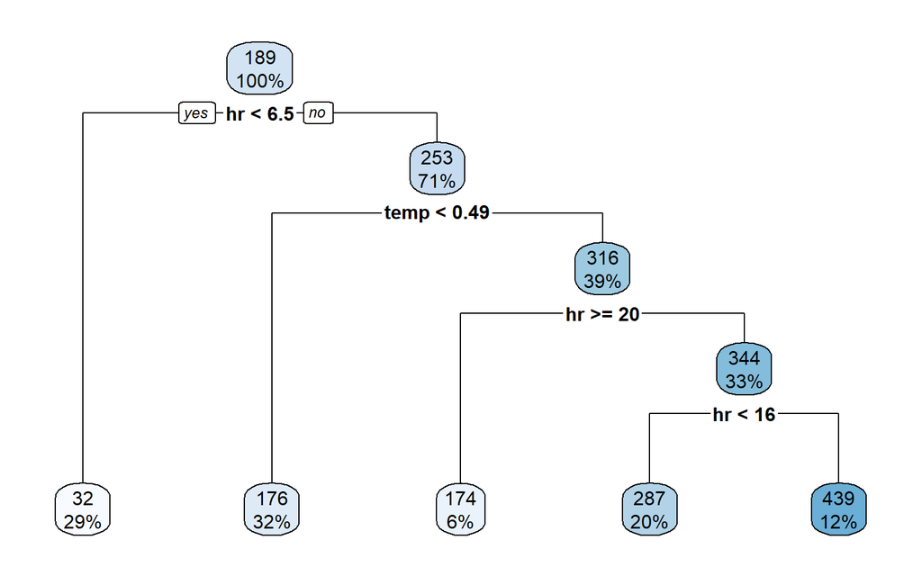

```r
simple_tree <- rpart::rpart(cnt~., data = Bike, method = "anova", cp = 0.03)
rpart.plot::rpart.plot(simple_tree)
```

Simple decision tree are interesting to review, but poor when it comes to predictive power.

## Random Forest

Algorithms based on decision trees are often very good for predictive analytics. The first we will compare is the random forest algorithm (there are many variations, the one below is just one. In a future update perhaps I’ll add a `ranger` model too.)

Random forests uses decision trees, which are very prone to overfitting. In order to achieve higher accuracy, RF decides to create a large number of them based on bagging. The basic idea is to resample the data over and over and for each sample train a new classifier. Different classifiers overfit the data in a different way, and through voting those differences are averaged out.

```r
set.seed <- 12347
trainctrl <- trainControl(method = "repeatedcv", number = 10, repeats = 3, verboseIter = TRUE)
#Decision Tree
#This version does not like the column names, so do not use the formula method
#rpart_tree <- train(cnt~., data = Bike1, method = "rpart", trControl = trainctrl)

rpart_tree <- train(x = Bike[, names(Bike) != "cnt"], y = Bike$cnt,
                    method = "rpart", trControl = trainctrl)

#Random Forest
rf_tree <- train(cnt~., data = Bike, method = "rf",  trControl = trainctrl)
```

```r
resamps <- resamples(list(singleTree=rpart_tree, randomForest=rf_tree))
summary(resamps)
```

```
##
## Call:
## summary.resamples(object = resamps)
##
## Models: singleTree, randomForest
## Number of resamples: 10
##
## MAE
##                  Min.  1st Qu.   Median     Mean  3rd Qu.      Max. NA's
## singleTree   88.49710 90.15725 97.21790 95.07333 98.91342 100.64581    0
## randomForest 41.44773 41.99263 42.44241 42.43909 42.91052  43.32864    0
##
## RMSE
##                   Min.   1st Qu.    Median     Mean   3rd Qu.      Max.
## singleTree   125.65004 129.16549 137.53168 134.9395 139.39865 141.95569
## randomForest  63.08688  64.37495  64.61998  64.6512  65.20592  65.92549
##              NA's
## singleTree      0
## randomForest    0
##
## Rsquared
##                   Min.   1st Qu.    Median      Mean   3rd Qu.      Max.
## singleTree   0.3930403 0.4102941 0.4171396 0.4454940 0.4996134 0.5112799
## randomForest 0.8699026 0.8708140 0.8746335 0.8737823 0.8758294 0.8780464
##              NA's
## singleTree      0
## randomForest    0
```

The random forest RMSE is nearly half that of the decision tree. Can we do better?

## Gradient Boosted Tree

Next, run a gradient boosted tree algorithm (GBM). Think of it as a random forest of steroids (data scientists - forgive me!)

Gradient Boosted Models (GBM) is a boosting method, which builds on weak classifiers. The idea is to add a classifier at a time, so that the next classifier is trained to improve the already trained ensemble. Notice that for random forest each iteration the classifier is trained independently from the rest.

```r
gbm_tree <- train(cnt~., data = Bike, method = "gbm", trControl = trainctrl,
                  distribution = "gaussian")
gbm_tree
```

```r
resamps <- resamples(list(singleTree=rpart_tree, randomForest=rf_tree, GBM = gbm_tree))
summary(resamps)
```

```
##
## Call:
## summary.resamples(object = resamps)
##
## Models: singleTree, randomForest, GBM
## Number of resamples: 10
##
## MAE
##                  Min.  1st Qu.   Median     Mean  3rd Qu.      Max. NA's
## singleTree   88.49710 90.15725 97.21790 95.07333 98.91342 100.64581    0
## randomForest 41.44773 41.99263 42.44241 42.43909 42.91052  43.32864    0
## GBM          57.89164 59.70480 60.05100 59.79845 60.35551  60.54485    0
##
## RMSE
##                   Min.   1st Qu.    Median      Mean   3rd Qu.      Max.
## singleTree   125.65004 129.16549 137.53168 134.93954 139.39865 141.95569
## randomForest  63.08688  64.37495  64.61998  64.65120  65.20592  65.92549
## GBM           82.77404  85.57403  86.04469  85.66981  86.44251  86.91901
##              NA's
## singleTree      0
## randomForest    0
## GBM             0
##
## Rsquared
##                   Min.   1st Qu.    Median      Mean   3rd Qu.      Max.
## singleTree   0.3930403 0.4102941 0.4171396 0.4454940 0.4996134 0.5112799
## randomForest 0.8699026 0.8708140 0.8746335 0.8737823 0.8758294 0.8780464
## GBM          0.7719539 0.7767903 0.7813793 0.7814993 0.7863368 0.7890998
##              NA's
## singleTree      0
## randomForest    0
## GBM             0
```

Hmm, the GBM did not perform as well as the random forest. Lets review what parameters we might change:

```r
getModelInfo()$gbm$parameters
```

```
##           parameter   class                   label
## 1           n.trees numeric   # Boosting Iterations
## 2 interaction.depth numeric          Max Tree Depth
## 3         shrinkage numeric               Shrinkage
## 4    n.minobsinnode numeric Min. Terminal Node Size
```

Below, we will evaluate 400 combinations or parameter values. Because we are using cross-validation to minimize overfitting, the code will run the 400 combinations over 10 folds 3 times! You do the math - lot is a lot of model experiments!

```r
myGrid <- expand.grid(n.trees = c(150, 175, 200, 250),
                      interaction.depth = c(5, 6, 7, 8, 9),
                      shrinkage = c(0.075, 0.1, 0.125, 0.15, 0.2),
                      n.minobsinnode = c(7, 10, 12, 15))

gbm_tree2 <- train(cnt~., data = Bike, method = "gbm", trControl = trainctrl,
                  distribution = "gaussian", tuneGrid = myGrid)
#By default, RMSE, R2, and the mean absolute error (MAE) are computed for regression
#while accuracy and Kappa are computed for classification.
```

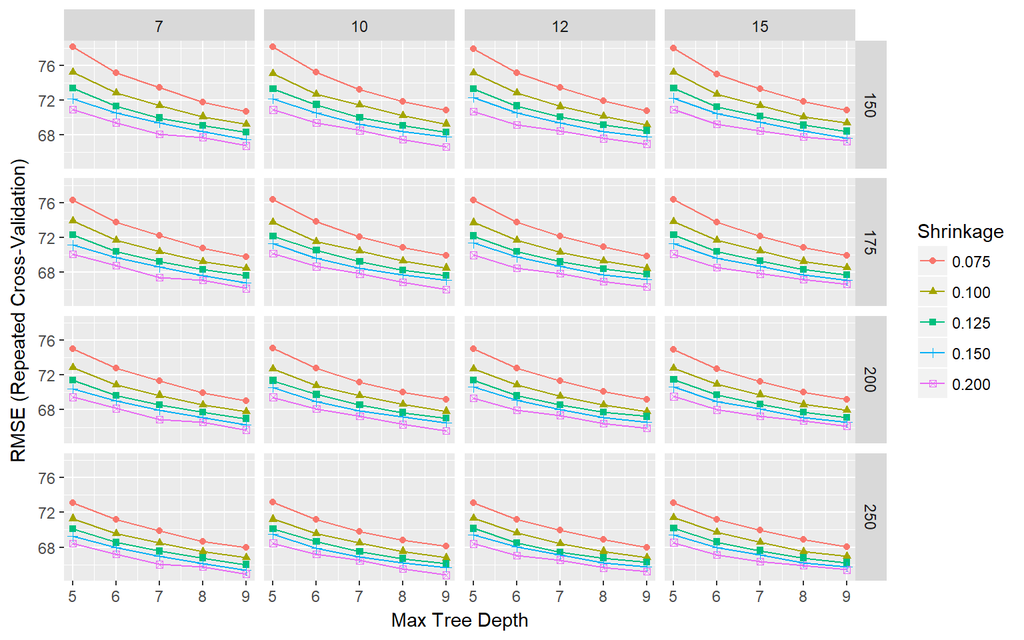

```r
ggplot(gbm_tree2)
```

There is much information above that suggests `expand.grid` parameters be reviewed /changed. That is left to the reader to test and evaluate.

Below, lets review the set of parameters that provide the highest performing model.

```r
gbm_tree2$bestTune
```

```
##     n.trees interaction.depth shrinkage n.minobsinnode
## 392     250                 9       0.2             10
```

The resulting RMSE is:

```r
gbm_tree2$results$RMSE[392]
```

```
## [1] 66.23439
```

Compare the model developed so far.

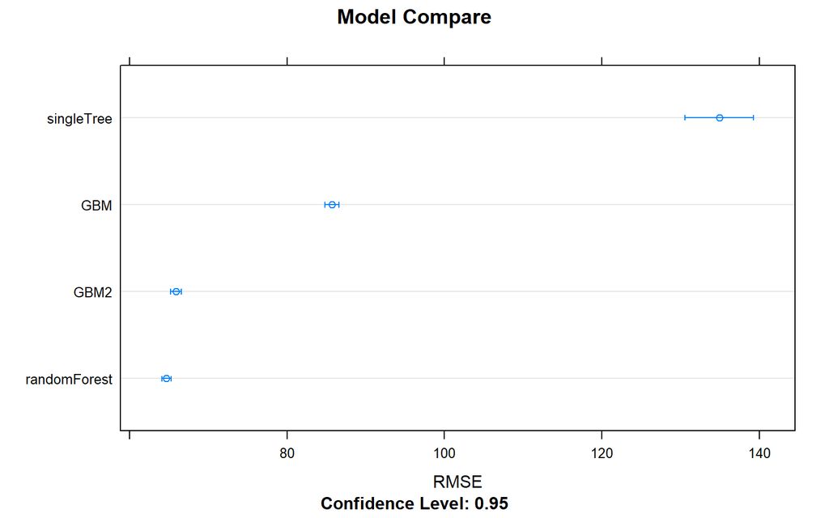

```r
resamps <- resamples(list(singleTree=rpart_tree, randomForest=rf_tree, GBM = gbm_tree, GBM2 = gbm_tree21))
dotplot(resamps, metric = "RMSE", main = "Model Compare")
```

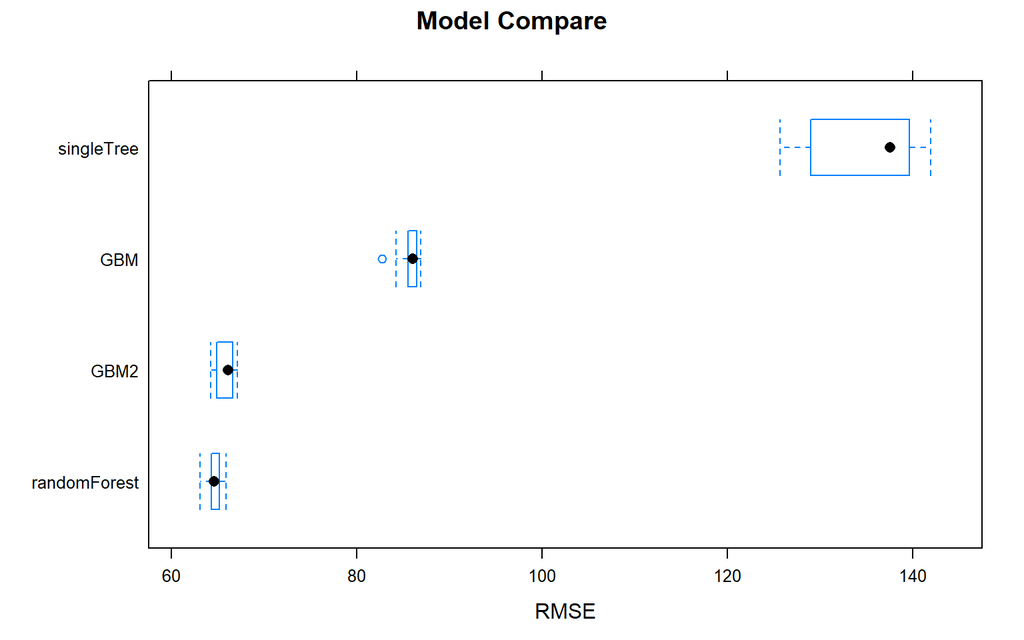

```r
bwplot(resamps, metric = "RMSE", main = "Model Compare")
```

## xgBoost

`xgBoost` is one of the most popular tree algorithms and one that often is used to place well in [Kaggle Competitions](https://www.kaggle.com/).

Let’s try this below.

```r
set.seed = 12345

library(xgboost)
library(Matrix)
#handles missing values
#requires matrix as input - all numerical values

#Partition data

myIndex <- sample(2, nrow(Bike), replace = TRUE,  prob = c(.8, .2))

myTrain <-  Bike[myIndex == 1,]
myTest <- Bike[myIndex == 2,]

#Recall there are 2 factors - use one hot encoding & create matrix
# cnt is in the 12th column (names(Bike1))

#First need to remove spaces in column names - xgboost does not like these!
names(myTrain) <- gsub("\\s", "_", names(myTrain))
names(myTrain) <- gsub("-", "_", names(myTrain))

names(myTest) <- gsub("\\s", "_", names(myTest))
names(myTest) <- gsub("-", "_", names(myTest))

myTrain_m <- sparse.model.matrix(cnt ~. -cnt, data = myTrain)
myTrain_label <-  myTrain[, "cnt"]

myTrain_matrix <- xgb.DMatrix(data = as.matrix(myTrain_m), label = myTrain_label)

#Do same thing for Test data
myTest_m <- sparse.model.matrix(cnt ~. -cnt, data = myTest)
myTest_label <-  myTest[, "cnt"]

myTest_matrix <- xgb.DMatrix(data = as.matrix(myTest_m), label = myTest_label)

#Parameters
xgb_params <- list("objective" = "reg:linear", "eval_metric" = "rmse")
watchlist <- list(train = myTrain_matrix, test = myTest_matrix)

best_model <- xgb.train(params = xgb_params, data = myTrain_matrix, nrounds = 100,
                        watchlist = watchlist)
```

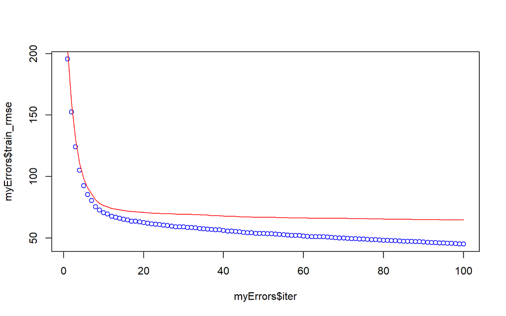

```r
#Plot results
myErrors <- data.frame(best_model$evaluation_log)
{plot(myErrors$iter, myErrors$train_rmse, col = "blue")
lines(myErrors$iter, myErrors$test_rmse, col = "red")}
```

```r
min(myErrors$test_rmse)
```

```
## [1] 64.83493
```

```r
myErrors[myErrors$test_rmse == min(myErrors$test_rmse),]
```

```
##    iter train_rmse test_rmse
## 99   99   45.29877  64.83493
```

Notice the separation between the red line (the test data) and the blue one (training data)? This is an indication the model is overfitting the data. We can change the model parameters to close this gap.

- lower eta is robust to overfitting. Default = 0.3; can range 0-1

```r
best_model <- xgb.train(params = xgb_params, data = myTrain_matrix, nrounds = 100,
                        watchlist = watchlist,  eta = 0.08)
```

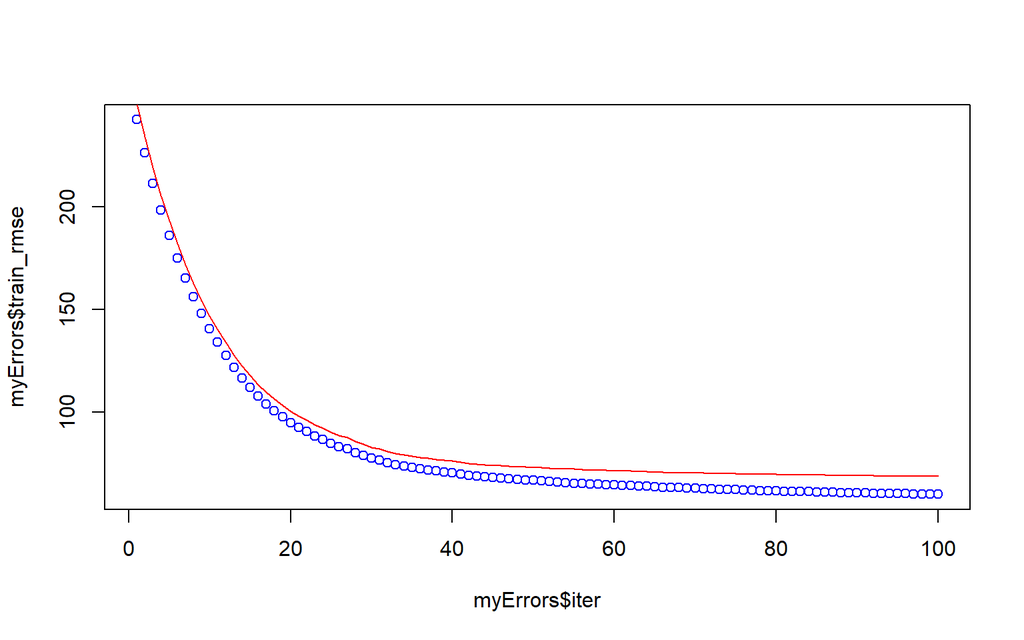

```r
#Plot results
myErrors <- data.frame(best_model$evaluation_log)
{plot(myErrors$iter, myErrors$train_rmse, col = "blue")
lines(myErrors$iter, myErrors$test_rmse, col = "red")}
```

Improved but can we do even better?

- `tree.depth`; default = 6; 1 to INF
- larger values of `gamma` produces more conservative algo (avoid overfitting); range 0 - INF; default = 0
- lower values of `subsample` helps prevent overfitting. Default = 1 (100%). Range 0 - 1. subsample ratio of the training instance. Setting it to 0.5 means that XGBoost randomly collected half of the data instances to grow trees and this will prevent overfitting.
- `colsample_bytree` default = 1. subsample ratio of columns when constructing each tree.
- `missing` very useful when dealing with large data and much missing data

```r
#http://xgboost.readthedocs.io/en/latest/parameter.html
best_model <- xgb.train(params = xgb_params, data = myTrain_matrix, nrounds = 300,
                        watchlist = watchlist, eta = 0.02, max.depth = 5, gamma = 50,
                        subsample = .5, colsample_bytree = .9, missing = NA, seed = 12345)
```

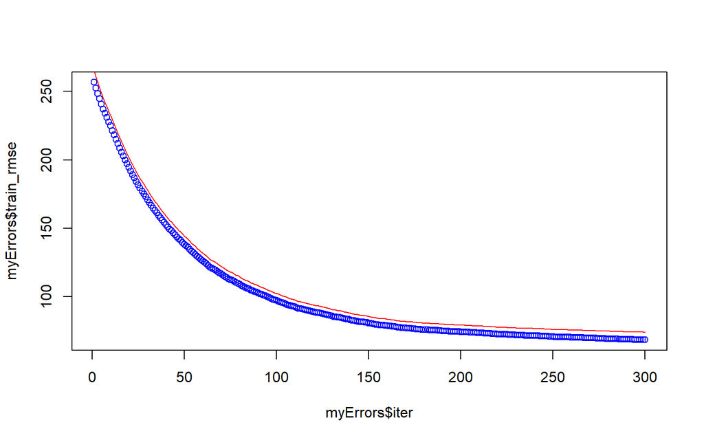

```r
#Plot results
myErrors <- data.frame(best_model$evaluation_log)
{plot(myErrors$iter, myErrors$train_rmse, col = "blue")
lines(myErrors$iter, myErrors$test_rmse, col = "red")}
```

```r
best_model$evaluation_log[300]
```

```
##    iter train_rmse test_rmse
## 1:  300   68.31176  73.87967
```

Review the variables that are most important as identified by xgBoost.

```r
myImportance <- xgb.importance(colnames(myTrain_matrix), model = best_model)
print(myImportance)#Gain is most important
```

```
##         Feature         Gain       Cover  Frequency
##  1:          hr 0.5982014943 0.403872930 0.28945299
##  2:        temp 0.1063824430 0.095167962 0.11838706
##  3:  workingday 0.1048859227 0.064383483 0.08570145
##  4:       atemp 0.0770586165 0.097198709 0.08379198
##  5:         hum 0.0393287105 0.107408085 0.10850275
##  6:     season4 0.0165417894 0.031137736 0.02504774
##  7:     weekday 0.0163229121 0.041640116 0.08491520
##  8:        mnth 0.0157319149 0.050696505 0.07368303
##  9: weathersit3 0.0153431681 0.032516841 0.02560935
## 10:   windspeed 0.0057538288 0.054556097 0.06177693
## 11:     holiday 0.0016349269 0.007837769 0.01662361
## 12:     season3 0.0011508988 0.002765802 0.00595305
## 13: weathersit2 0.0010614431 0.008349972 0.00999663
## 14:     season2 0.0006019311 0.002467994 0.01055824
```

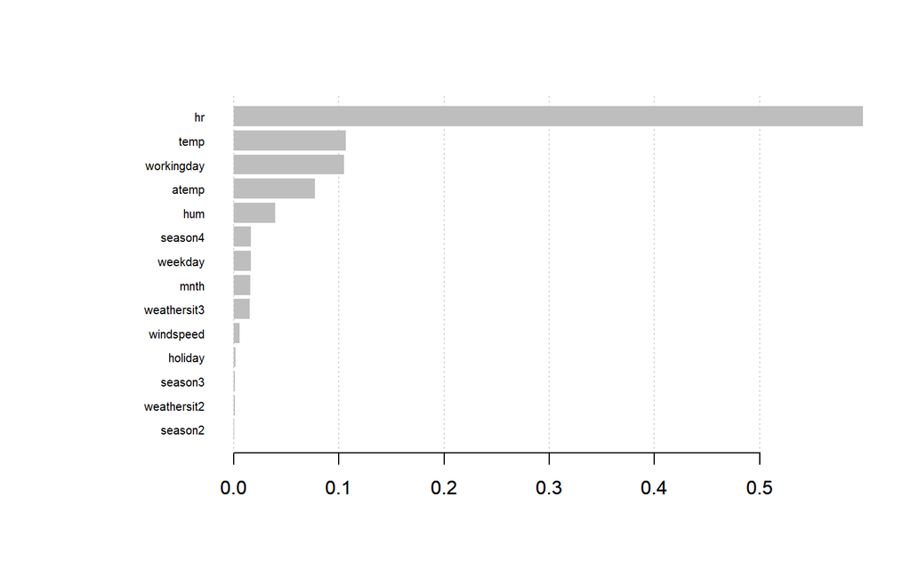

```r
xgb.plot.importance(myImportance)
```

Finally, lets peek at some predictions.

```r
myPredictions <- predict(best_model, newdata = myTest_matrix)

myCompare <- data.frame(Prediction = myPredictions, Actual = myTest$cnt)
head(myCompare, 20)
```

```
##    Prediction Actual
## 1    2.072189      1
## 2    8.492558      2
## 3   55.201004      8
## 4  263.792145     94
## 5  270.442444    106
## 6  242.783188    110
## 7  189.498016     67
## 8   61.968243     17
## 9  184.505417     70
## 10 155.066879     59
## 11 151.023941     76
## 12  36.156689      9
## 13  40.613941     30
## 14 135.879959     88
## 15  89.256157     61
## 16 266.310577    179
## 17 142.860474    100
## 18 110.923836     65
## 19 159.234116     88
## 20  66.836372     57
```

# Run Models with Featured Engineered Data

So far, we have evaluated only the original data set. It would be a shame to not use the data we created in the feature engineering section. Use the models we have explored and test them against the datasets were created in the beginning of this exercise.

Evaluate the Random Forest, GBM2 and xgBoost models with each of the datasets created earlier and compare the results.

Recall:

- **Bike1** = number of bikes that were rented in each of the previous 12 hours
- **Bike2** = number of bikes that were rented in each of the previous 12 days at the same hour
- **Bike3** = number of bikes that were rented in each of the previous 12 weeks at the same hour and the same day

## Decision Tree

For the basic decision tree, run the algorithm using eack of the datasets (Bike1, Bike2, Bike3) and calculate the mean RMSE.

```r
#Manually reran code subbing Bike with Bike1, Bike2, Bike3
rpart_tree <- train(x = Bike3[, names(Bike3) != "cnt"], y = Bike3$cnt,
                    method = "rpart", trControl = trainctrl)
```

```r
mean(rpart_tree$results$RMSE)
```

```
## [1] 121.3325
```

## Random Forests

Same algorithm used earlier ran 3 times, once for each of the Bike* datasets.

```r
#run model in parallel
library(doParallel)
cl <- makeCluster(detectCores())
registerDoParallel(cl)

set.seed <- 12347
trainctrl <- trainControl(method = "repeatedcv", number = 10, repeats = 3, verboseIter = TRUE)

#Random Forest
rf_tree1 <- train(cnt~., data = Bike1, method = "rf",  trControl = trainctrl)
rf_tree2 <- train(cnt~., data = Bike2, method = "rf",  trControl = trainctrl)
rf_tree3 <- train(cnt~., data = Bike3, method = "rf",  trControl = trainctrl)
rfResults <- resamples(list(rfBike1=rf_tree1, rfBike2=rf_tree2, rfBike3=rf_tree3))

stopCluster(cl)
```

```r
summary(rfResults)
```

```
##
## Call:
## summary.resamples(object = rfResults)
##
## Models: rfBike1, rfBike2, rfBike3
## Number of resamples: 30
##
## MAE
##             Min.  1st Qu.   Median     Mean  3rd Qu.     Max. NA's
## rfBike1 19.11338 19.74217 20.09657 20.05775 20.26735 21.23204    0
## rfBike2 20.76917 21.57728 22.06923 22.05606 22.51158 23.13996    0
## rfBike3 21.14136 22.01225 22.48183 22.38857 22.72405 23.65919    0
##
## RMSE
##             Min.  1st Qu.   Median     Mean  3rd Qu.     Max. NA's
## rfBike1 29.76596 32.05312 32.70131 32.65167 33.68490 35.48419    0
## rfBike2 33.49693 35.27730 36.56251 36.32678 37.19464 39.22184    0
## rfBike3 34.22100 35.93828 37.96330 37.63611 39.26774 40.62131    0
##
## Rsquared
##              Min.   1st Qu.    Median      Mean   3rd Qu.      Max. NA's
## rfBike1 0.9615340 0.9660285 0.9680254 0.9676784 0.9689821 0.9732548    0
## rfBike2 0.9515224 0.9576180 0.9601160 0.9603321 0.9628630 0.9677699    0
## rfBike3 0.9472027 0.9541264 0.9557577 0.9570198 0.9611795 0.9666060    0
```

## GBM

Same optimized algorithm used earlier ran 3 times, once for each of the Bike* datasets.

```r
#PC rebooted before models completed.  Lost a week of processing.  Changed folding to get this completed faster.
set.seed <- 12347
trainctrl <- trainControl(method = "repeatedcv", number = 5, repeats = 2, verboseIter = TRUE)

myGrid <- expand.grid(n.trees = c(150, 175, 200, 250),
                      interaction.depth = c(5, 6, 7, 8, 9),
                      shrinkage = c(0.075, 0.1, 0.125, 0.15, 0.2),
                      n.minobsinnode = c(7, 10, 12, 15))

gbm_treeBike1 <- train(cnt~., data = Bike1, method = "gbm", trControl = trainctrl,
                  distribution = "gaussian", tuneGrid = myGrid)
gbm_treeBike2 <- train(cnt~., data = Bike2, method = "gbm", trControl = trainctrl,
                  distribution = "gaussian", tuneGrid = myGrid)
gbm_treeBike3 <- train(cnt~., data = Bike3, method = "gbm", trControl = trainctrl,
                  distribution = "gaussian", tuneGrid = myGrid)
```

```r
gbmresults <- resamples(list(gbmBike1=gbm_treeBike1, gbmBike2=gbm_treeBike2,
                             gbmBike3=gbm_treeBike3))
summary(gbmresults)
```

```
##
## Call:
## summary.resamples(object = gbmresults)
##
## Models: gbmBike1, gbmBike2, gbmBike3
## Number of resamples: 10
##
## MAE
##              Min.  1st Qu.   Median     Mean  3rd Qu.     Max. NA's
## gbmBike1 21.97461 22.02022 22.06128 22.22330 22.34160 22.83680    0
## gbmBike2 22.68867 22.81420 22.93065 23.09640 23.29401 24.02597    0
## gbmBike3 22.61658 23.21083 23.44840 23.31175 23.49940 23.71916    0
##
## RMSE
##              Min.  1st Qu.   Median     Mean  3rd Qu.     Max. NA's
## gbmBike1 33.77209 33.98491 34.40182 34.44176 34.64867 35.53636    0
## gbmBike2 34.39622 34.82963 35.26999 35.35826 35.45735 37.22720    0
## gbmBike3 34.39690 35.53978 35.81362 35.86418 36.35826 36.98347    0
##
## Rsquared
##               Min.   1st Qu.    Median      Mean   3rd Qu.      Max. NA's
## gbmBike1 0.9621183 0.9633908 0.9641289 0.9639772 0.9645387 0.9655172    0
## gbmBike2 0.9578713 0.9618218 0.9621099 0.9620224 0.9626195 0.9645729    0
## gbmBike3 0.9587621 0.9598372 0.9610787 0.9609428 0.9619938 0.9631946    0
```

## xgBoost

Same optimized algorithm used earlier ran 3 times, once for each of the Bike* datasets.

```r
#Performed this manually by simply change the siffix to the Bike dataset
myIndex <- sample(2, nrow(Bike3), replace = TRUE,  prob = c(.8, .2))

myTrain <-  Bike1[myIndex == 1,]
myTest <- Bike1[myIndex == 2,]

#Recall there are 2 factors - use one hot encoding & create matrix
# cnt is in the 12th column (names(Bike1))

#First need to remove spaces in column names - xgboost does not like these!
names(myTrain) <- gsub("\\s", "_", names(myTrain))
names(myTrain) <- gsub("-", "_", names(myTrain))

names(myTest) <- gsub("\\s", "_", names(myTest))
names(myTest) <- gsub("-", "_", names(myTest))

myTrain_m <- sparse.model.matrix(cnt ~. -cnt, data = myTrain)
myTrain_label <-  myTrain[, "cnt"]

myTrain_matrix <- xgb.DMatrix(data = as.matrix(myTrain_m), label = myTrain_label)

#Do same thing for Test data
myTest_m <- sparse.model.matrix(cnt ~. -cnt, data = myTest)
myTest_label <-  myTest[, "cnt"]

myTest_matrix <- xgb.DMatrix(data = as.matrix(myTest_m), label = myTest_label)

#Parameters
xgb_params <- list("objective" = "reg:linear", "eval_metric" = "rmse")
watchlist <- list(train = myTrain_matrix, test = myTest_matrix)

best_model <- xgb.train(params = xgb_params, data = myTrain_matrix, nrounds = 300,
                        watchlist = watchlist, eta = 0.02, max.depth = 5, gamma = 50,
                        subsample = .5, colsample_bytree = .9, missing = NA, seed = 12345)
rm(myIndex, myTrain, myTest, myTrain_m, myTrain_label, myTest_matrix, myTrain_matrix, myTest_m)
```

- Bike1 - train-rmse:30.957346 test-rmse:36.111832
- Bike2 - train-rmse:31.022646 test-rmse:36.340450
- Bike3 - train-rmse:31.362427 test-rmse:34.209591

xgBoost performs best with the Bike1 and Bike3 data. I think in this case, I prefer the model based on Bike3 because the test RMSE is less. In practice, I would evaluate both models further before going into production,